# Reproducible Research, Assignment One

AJ

October 5, 2016

## Introduction

JHU Coursera – Reproducible Research (Course 5), Week 2 Assignment

## Prep Enviroment

```r
rm(list = ls())
setwd("C:/Users/akash/Desktop/StatsCourses/JHU_Specialization/Course5/w2")
library(ggplot2)
library(knitr)
opts_chunk$set(echo = TRUE, results = 'hold')
```

## Load Data

#### Assumes datafile is in setwd

```r
rdata <- read.csv('activity.csv', header = TRUE, sep = ",",
            colClasses=c("numeric", "character", "numeric"))
```

## Tidy The Data

```r
rdata$date <- as.Date(rdata$date, format = "%Y-%m-%d")
rdata$interval <- as.factor(rdata$interval)
```

#### Check

```r
str(rdata)
```

```
## 'data.frame':    17568 obs. of  3 variables:
##  $ steps   : num  NA NA NA NA NA NA NA NA NA NA ...
##  $ date    : Date, format: "2012-10-01" "2012-10-01" ...
##  $ interval: Factor w/ 288 levels "0","5","10","15",..: 1 2 3 4 5 6 7 8 9 10 ...
```

## **What Is The Mean Total Number Of Steps Taken Per Day?**

#### Total Number Of Steps Taken Per Day

```r
steps_per_day <- aggregate(steps ~ date, rdata, sum)
colnames(steps_per_day) <- c("date","steps")
head(steps_per_day)
```

```
##         date steps
## 1 2012-10-02   126
## 2 2012-10-03 11352
## 3 2012-10-04 12116
## 4 2012-10-05 13294
## 5 2012-10-06 15420
## 6 2012-10-07 11015
```

#### Histogram: Total Number of Steps Taken Per Day

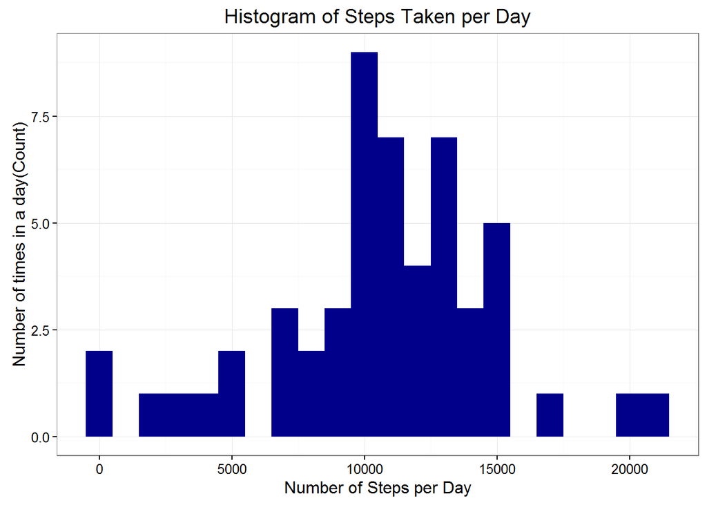

```r
ggplot(steps_per_day, aes(x = steps)) +
    geom_histogram(fill = "blue4", binwidth = 1000) +
    labs(title="Histogram of Steps Taken per Day",
    x = "Number of Steps per Day",
    y = "Number of times in a day(Count)") + theme_bw()
```

#### Mean And Median: Total Number Of Steps Taken Per Day

```r
steps_mean   <- mean(steps_per_day$steps, na.rm=TRUE)
steps_median <- median(steps_per_day$steps, na.rm=TRUE)
```

The mean is **10766.189** and median is **10765**.

## **What is the Average Daily Activity Pattern?**

#### Time Series Plot: Average Number Of Steps Taken (Averaged Across All Days) Vs the 5-Minute Intervals

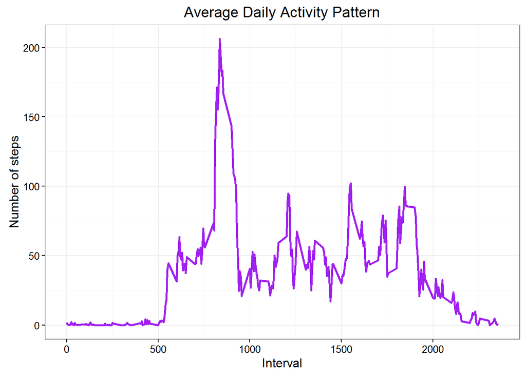

```r
steps_per_interval <- aggregate(rdata$steps,
    by = list(interval = rdata$interval), FUN=mean, na.rm=TRUE)
steps_per_interval$interval <- as.integer(levels(steps_per_interval$interval)[steps_per_interval$interval])
colnames(steps_per_interval) <- c("interval", "steps")
ggplot(steps_per_interval, aes(x=interval, y=steps)) +
    geom_line(color="purple", size=1) +
    labs(title="Average Daily Activity Pattern", x="Interval",
    y="Number of steps") + theme_bw()
```

#### Max 5 Minute Interva;

```r
max_interval <- steps_per_interval[which.max(steps_per_interval$steps),]
```

The **835<sup>th</sup>** interval has maximum **206** steps.

## **Imputing Missing Values**

###### Note that there are a number of days/intervals where there are missing values (coded as NA). The presence of missing days may introduce bias into some calculations or summaries of the data.

#### Total Number Of Missing Values

```r
missing_vals <- sum(is.na(rdata$steps))
```

The total number of missing values are **2304**.

#### Solution: How To Fix The N/As

```r
na_fill <- function(data, pervalue) {
        na_index <- which(is.na(data$steps))
        na_replace <- unlist(lapply(na_index, FUN=function(idx){
                interval = data[idx,]$interval
                pervalue[pervalue$interval == interval,]$steps
        }))
        fill_steps <- data$steps
        fill_steps[na_index] <- na_replace
        fill_steps
}

rdata_fill <- data.frame(
        steps = na_fill(rdata, steps_per_interval),
        date = rdata$date,
        interval = rdata$interval)
str(rdata_fill)
```

```
## 'data.frame':    17568 obs. of  3 variables:
##  $ steps   : num  1.717 0.3396 0.1321 0.1509 0.0755 ...
##  $ date    : Date, format: "2012-10-01" "2012-10-01" ...
##  $ interval: Factor w/ 288 levels "0","5","10","15",..: 1 2 3 4 5 6 7 8 9 10 ...
```

#### Check

```r
sum(is.na(rdata_fill$steps))
```

```
## [1] 0
```

Zero output shows that there are *no missing values*.

#### Histogram: Total Number of Steps Taken Per Day (With Filled In N/As)

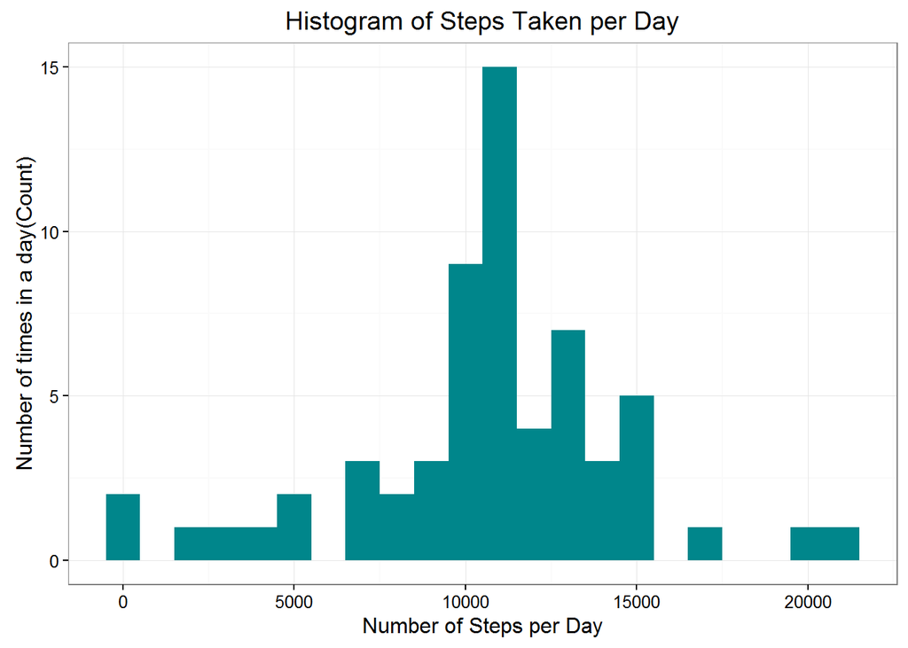

```r
fill_steps_per_day <- aggregate(steps ~ date, rdata_fill, sum)
colnames(fill_steps_per_day) <- c("date","steps")
ggplot(fill_steps_per_day, aes(x = steps)) +
       geom_histogram(fill = "turquoise4", binwidth = 1000) +
       labs(title="Histogram of Steps Taken per Day",
       x = "Number of Steps per Day",
       y = "Number of times in a day(Count)") + theme_bw()
```

#### Mean And Median: Total Number Of Steps Taken Per Day (With Filled In N/As)

```r
steps_mean_fill   <- mean(fill_steps_per_day$steps, na.rm=TRUE)
steps_median_fill <- median(fill_steps_per_day$steps, na.rm=TRUE)
```

The mean is **10766.189** and median is **10766.189**.

#### Do these values differ from the estimates from the first part of the assignment?

##### Before Filling In N/As

```
Mean  : 10766.189
Median: 10765
```

##### After Filling In N/As

```
Mean  : 10766.189
Median: 10766.189
```

The mean is virtually the same in Before vs After but the median slightly increases.

## **Are There Differences In Activity Patterns Between Weekdays And Weekends?**

```r
weekdays_steps <- function(data) {
    weekdays_steps <- aggregate(data$steps, by=list(interval = data$interval),
                          FUN=mean, na.rm=T)

    weekdays_steps$interval <-
            as.integer(levels(weekdays_steps$interval)[weekdays_steps$interval])
    colnames(weekdays_steps) <- c("interval", "steps")
    weekdays_steps
}

data_by_weekdays <- function(data) {
    data$weekday <-
            as.factor(weekdays(data$date)) # weekdays
    weekend_data <- subset(data, weekday %in% c("Saturday","Sunday"))
    weekday_data <- subset(data, !weekday %in% c("Saturday","Sunday"))

    weekend_steps <- weekdays_steps(weekend_data)
    weekday_steps <- weekdays_steps(weekday_data)

    weekend_steps$dayofweek <- rep("weekend", nrow(weekend_steps))
    weekday_steps$dayofweek <- rep("weekday", nrow(weekday_steps))

    data_by_weekdays <- rbind(weekend_steps, weekday_steps)
    data_by_weekdays$dayofweek <- as.factor(data_by_weekdays$dayofweek)
    data_by_weekdays
}

data_weekdays <- data_by_weekdays(rdata_fill)
```

#### Panel Plot: Weekdays Vs Weekends

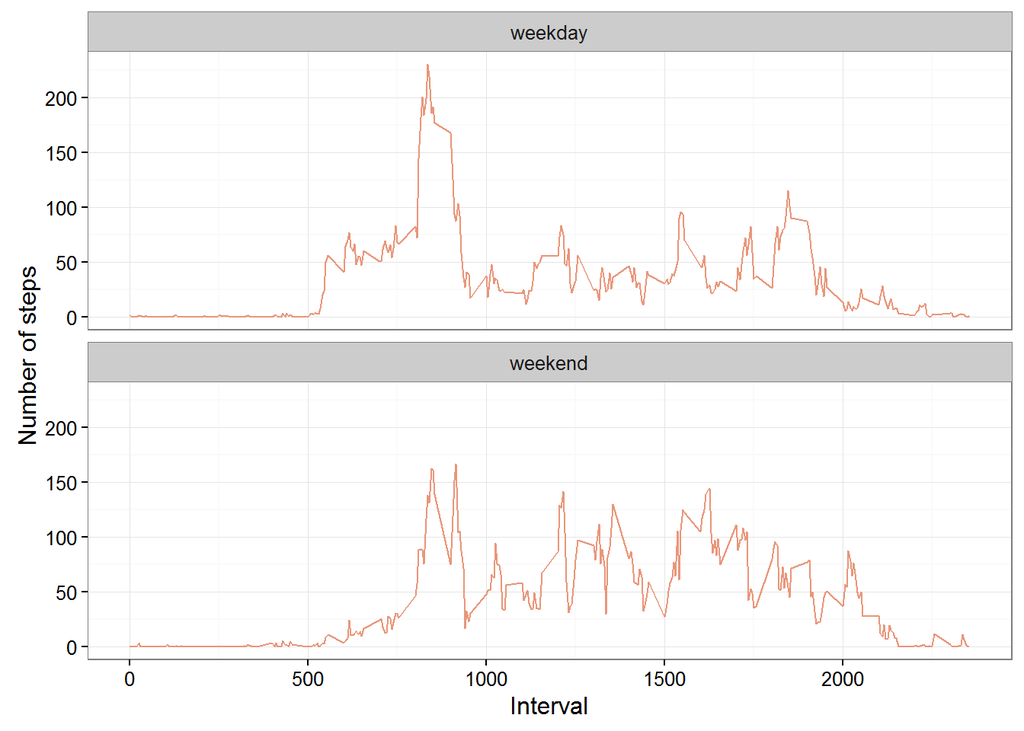

```r
ggplot(data_weekdays, aes(x=interval, y=steps)) +
        geom_line(color="darksalmon") +
        facet_wrap(~ dayofweek, nrow=2, ncol=1) +
        labs(x="Interval", y="Number of steps") +
        theme_bw()
```

##### Weekdays has the highest peak, but Weekend has more steps over 100.